# Chapter 5 Problem Set Solutions

```r
library(readxl)
library(ggplot2)
setwd("C:/Users/timma/Documents/GitHub/FIN6572Fall2020/Problem Sets/Ch5")
```

### 5.1

1. $\Pr(X<325) = \Pr\left(Z<\dfrac{325-330}{4}\right)$

```r
pnorm(325,330,4)
```

```
## [1] 0.1056498
```

2. $\Pr\left(\bar{X}<325| N=6\right)=\Pr\left(Z<\dfrac{325-330}{4/\sqrt{6}}\right)$

```r
pnorm(325,330,4/sqrt(6))
```

```
## [1] 0.001099824
```

```r
pnorm(325,330,4/sqrt(12))
```

```
## [1] 7.451168e-06
```

### 5.2

$\Pr\left(\bar{X}>200\right)=\Pr\left(Z>\dfrac{200-180}{28/\sqrt{16}}\right)$

```r
1-pnorm(200, 180, 28/sqrt(16))
```

```
## [1] 0.002137367
```

### 5.3

1. $\Pr\left(X>35\right)=\Pr\left(Z>\dfrac{35-33.8}{3.5}\right)$

```r
1-pnorm(35,33.8,3.5,1)
```

```
## [1] 0.365853
```

2. $\Pr\left(\bar{X}>35\right)=\Pr\left(Z>\dfrac{35-33.8}{3.5\sqrt(4)}\right)$

```r
1-pnorm(35,33.8,3.5/sqrt(4))
```

```
## [1] 0.2464466
```

3. $\left(\Pr\left(X>35\right)\right)^4$

```r
(1-pnorm(35,33.8,3.5))^4
```

```
## [1] 0.01791539
```

### 5.4

1. $\mathbb{E}\left[\hat{P}\right] = 1/6 \approx 0.17 = p$ $se\left(\hat{p}\right) = \sqrt{\dfrac{0.17(1-0.17)}{200}}$

```r
se = sqrt(((1/6)*(5/6))/200)
se
```

```
## [1] 0.02635231
```

$\Pr\left(\bar{P}>20\right) = \Pr\left(Z>\dfrac{0.20-0.17}{\sqrt{\frac{0.17(1-0.17)}{200}}}\right)$

Note: This is slightly off from the connect solution because why round when you don’t have to.

```r
1-pnorm(0.2,1/6,se)
```

```
## [1] 0.1029516
```

### 5.5

```r
myData = read_xlsx("Ch05_Q17_Data_File.xlsx")
```

A 90% confidence interval corresponds with an upper tail of 5% (0.95 in qt function gets this 95th percentile).

```r
Error = qt(0.95,5) * sd(myData$Customers)/sqrt(6)
Error
```

```
## [1] 40.88447
```

Construct 90% confidence interval from mean and margin of error.

```r
Lower = mean(myData$Customers) - Error
Upper = mean(myData$Customers) + Error
c(Lower,Upper)
```

```
## [1] 119.1155 200.8845
```

Alternatively, one can run a one-sample t-test.

```r
t.test(myData$Customers, conf.level=0.90)
```

```
##
##  One Sample t-test
##
## data:  myData$Customers
## t = 7.8858, df = 5, p-value = 0.0005272
## alternative hypothesis: true mean is not equal to 0
## 90 percent confidence interval:
##  119.1155 200.8845
## sample estimates:
## mean of x
##       160
```

### 5.6

```r
myData = read_xlsx("Ch05_Q25_Data_File.xlsx")
```

```r
t.test(myData$Debt, conf.level=0.90)
```

```
##
##  One Sample t-test
##
## data:  myData$Debt
## t = 40.244, df = 25, p-value < 2.2e-16
## alternative hypothesis: true mean is not equal to 0
## 90 percent confidence interval:
##   941.7184 1025.2047
## sample estimates:
## mean of x
##  983.4615
```

```r
t.test(myData$Debt, conf.level=0.95)
```

```
##
##  One Sample t-test
##
## data:  myData$Debt
## t = 40.244, df = 25, p-value < 2.2e-16
## alternative hypothesis: true mean is not equal to 0
## 95 percent confidence interval:
##   933.131 1033.792
## sample estimates:
## mean of x
##  983.4615
```

```r
sd(myData$Debt)
```

```
## [1] 124.6086
```

### 5.7

For 95% confidence interval, upper tail is 97.5th quantile, which is then scaled by standard deviation of the estimate.

```r
moe = qt(0.975,1025) * sqrt((0.47*(1-0.47))/1026)
moe
```

```
## [1] 0.03057556
```

```r
lb = 0.47 - moe
ub = 0.47 + moe
c(lb,ub)
```

```
## [1] 0.4394244 0.5005756
```

### 5.9

Calculate t-statistic:

```r
t = (2.8-3)*sqrt(45)
t
```

```
## [1] -1.341641
```

p-value:

```r
pt(t,44)
```

```
## [1] 0.09329802
```

### 5.10

```r
myData = read_xlsx("Ch05_Q47__Data_File.xlsx")
```

Plot histogram and investigate:

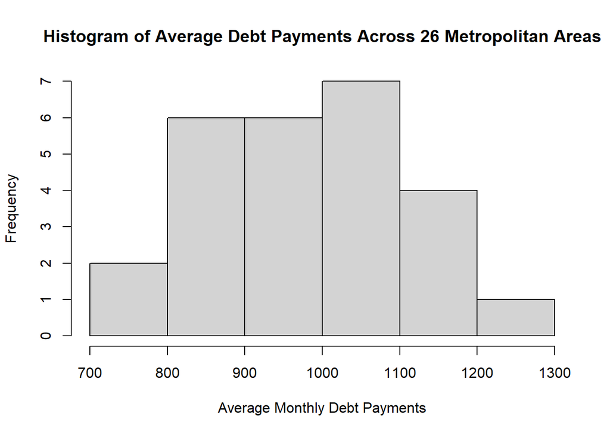

```r
hist(myData$Debt,
     main="Histogram of Average Debt Payments Across 26 Metropolitan Areas",
     xlab="Average Monthly Debt Payments",
     breaks=5)
```

Calculate t-statstic:

```r
mu = mean(myData$Debt)
s = sd(myData$Debt)
t = (900-mu)/(s/sqrt(length(myData$Debt)))
t
```

```
## [1] -3.415271
```

```r
t.test(myData$Debt, mu=900)
```

```
##
##  One Sample t-test
##
## data:  myData$Debt
## t = 3.4153, df = 25, p-value = 0.002182
## alternative hypothesis: true mean is not equal to 900
## 95 percent confidence interval:
##   933.131 1033.792
## sample estimates:
## mean of x
##  983.4615
```